# Stats for the reviewers comments

## Reviewer 1.

**The authors have important observations on the concomittant use of beta-blockers and ACE inhibitors and mores severe anaphylaxis; possibly a profund biostatistical analysis of this aspect could help to find out whether this is just due to the “premorbidity of this patients” or an effect of these drugs.**

This is a very important aspect, that we have also investigated previously. (https://www.ncbi.nlm.nih.gov/pubmed/25441633). We could partially investigate the influence of cardiologic drugs on the severity of anaphylaxis in a maouse model of anaphylaxis.

In our previous publication regarding risk factors in all types of anaphylaxis we have found that ACE-I and beta-blockers increased the risk of severe anaphylaxis - but also the effect of concomitant cardiologic conditions could not be isolated from the effects of drugs alone. Therefore a different experimental approach is needed to address this question.

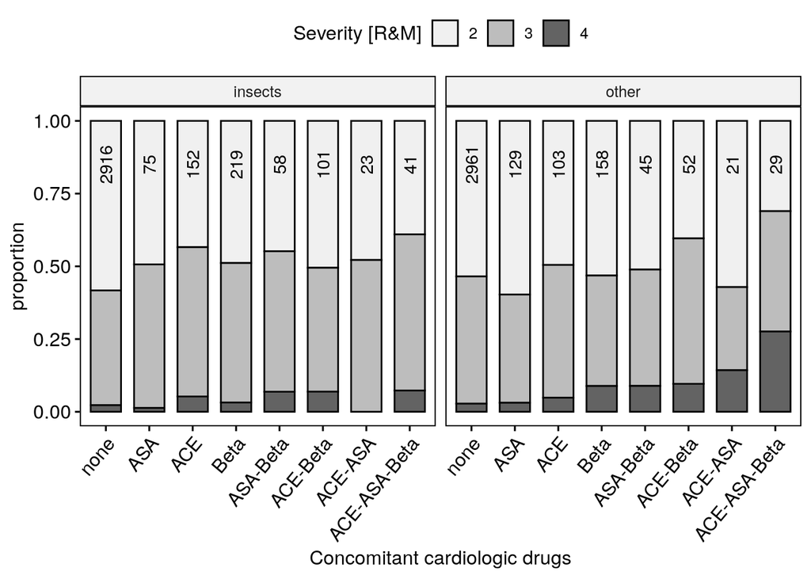

** Are there any data available on the latency time between sting and symptoms in correlation with the severity of the reaction?**

We thank the reviewer for this interesting question. Indeed we did not provide data on time between elicitor exposure and the onset of anaphylaxis symptoms, although this data was readily available to us. The figure below provides the missing data and is now added to the supplementary online material.

Please notice that patients with insect venom anaphylaxis more often had severe anaphylaxis if the reaction occured in the first 10 minutes after exposure to venom (46.58% of Ring and Messmer grade III or IV cases) then when the reaction occured after 10 minutes post exposure (39.75% p = 0.001). In patients from the control group there was no difference in the reaction severity if the reaction occured in 10 minutes or after 10 minutes post exposure (48.83% vs 47.44%, p = 0.4941).

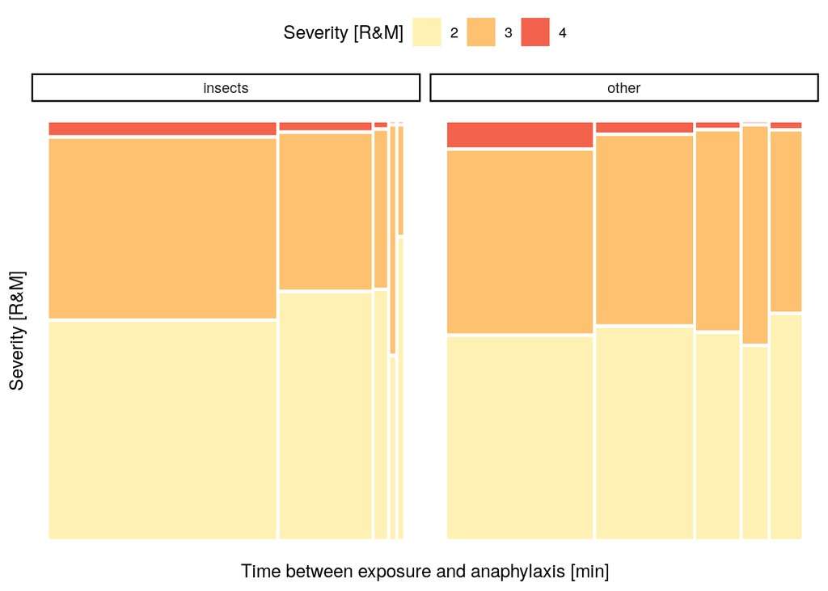

Time between exposure to an elicitor and first anaphylaxis symptoms. Patient undergoing anaphylaxis due to insects more often had a quick reaction during the first 10 minutes, whereas patients with non-VIA rected more often after 10 minutes. In the Insect venom anaphylaxis we saw a decrease in severity in these patients that reacted after 10 minutes.

**In the supplementary material (also very interesting) the authors mention in Fig 1 other insects. It would be good to mention briefly in the text what insecst these were (imported fire ants? others?)**

Indeed the mentioned “other insects” were fire ants reported from the centers in Brazil. We included this information in the figure description. We also saw 7 mosquittos and 5 horse flies. The rest of the other insects species could not be identified in the anamnesis (n = 137, 3.8% of all insect cases).

**References: there are 2 newer publications focussing on the similar topcis, possibly they could be added:**

**1. Risk factors and indicators of severe systemic insect sting reactions. Stoevesandt J, Sturm GJ, Bonadonna P, Oude Elberink JNG, Trautmann A. Allergy. 2019 Jun 13. doi: 10.1111/all.13945**

**2. Risk factors for severe systemic sting reactions in wasp (Vespula spp.) and honeybee (Apis mellifera) venom allergic patients. Fehr D, Micaletto S, Moehr T, Schmid-Grendelmeier P. Clin Transl Allergy. 2019 Oct 11;9:54.**

We have added these publications in the discussion.

## REVIEWER #2:

**Reviewer #2: MAJOR COMMENTS: The study “Phenotype and risk farctors of VIA: a case-control study of the European Anaphylaxis registry” evaluates in a meaningful number of patients including children and adults with VIA and non-VIA. The paper is a descriptive clinical study evaluating the severity of anaphylaxis, involved organs, levels of BST and treatment models and comparing these parameters between VIA and non-VIA. The study is a clinical descriptive study which does not bring a new concept or mechanistic innovative finding. My opinion is that the study is more appropriate for a journal with clinical perspective as JACIP, etc. The major strength of the study is the high number of the participants, It is well designed as a clinical and observational study,**

Major Concerns: **1. The method part includes a very short information about propensity score matching done by MatchIT package for R and the eFig 2 shows different ratio, it needs more information to understand the propensity score.**

We agree that the propensity score matching has not been in detail explained in our methods. We addedd aditional information to address this issue in the methods:

“Propensity score matching to sex, age and reaction severity, in order to reduce the comparison bias, has been performed using the”MatchIt" package for R. MatchIt uses logistic regression to reduce the bias due to confounding variables (i.e. sex and age) by minimizing differences in both groups after weighing and comparing multiple variables."

The supplementary figure caption also has been changed to:

“Results of matching the cohort according to sex and age in order to perform a case-controlled study. A: The original distribution of VIA and non-VIA cases according to age group and sex. Please note the uneaven distribution of VIA and non-VIA cases in age groups. B: The distribution of VIA and non-VIA after age and sex matching with the use of MatchIt package for R. Please notice how the ratio of VIA to non-VIA cases is approaching 50% indicating more balanced matching according to sex and age variables”

**2. Some of the patients registered were previously diagnosed as mastocytosis, wahat was the baseline tryptase level at these patients and which type of mastocytosis was the diagnosis and which criteria were positive for these pts?**

Thank you for this suggestion. The levels of BST are illustrated in the figure below. We think it is worth adding to the Supplementary online material.

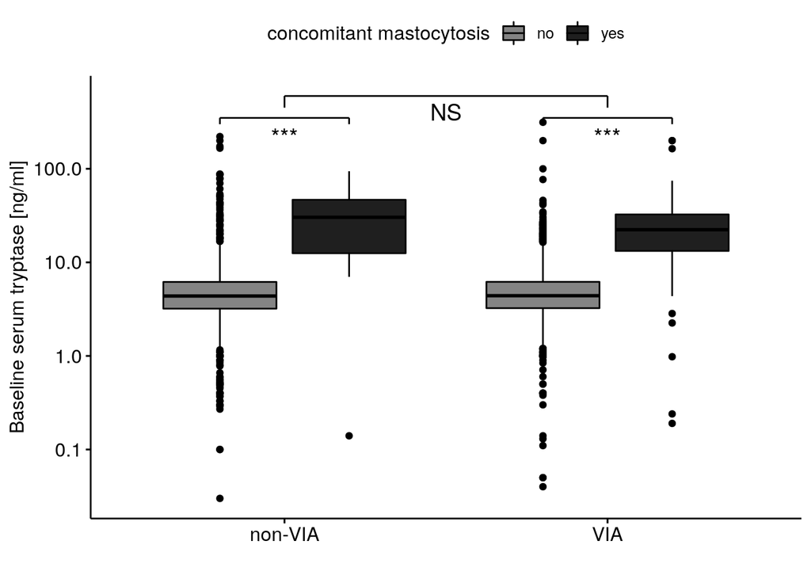

Levels of baseline serum tryptase in patinent with insect venom anaphylaxis and non-IVA. *** Significant difference in BST between patients with concomitant mastocytosis and other patients. NS - there was no significant difference between anaphylaxis elicited by insects or other elicitors. Tested by two way ANOVA.

After the reaction occures, and when patients present in a participating allergy center we ask patients about the previous diagnosis of mastocytosis. That means that patients who were considered having concomitant mastocytosis had already an externally confirmed diagnosis. Until recently, our anaphylaxis questionnaire did not include further questions about the classification of mastocytosis nor diagnosis criteria. But whenever a diagnosis of mastocytosis was already available they were classified as patients with concomitant mastocytosis in our study.

We agree with the reviewer that additional information regarding concomitant mastocytosis would provide additional analysis opportunities and therefore this data will be asked for in our updated questionnaires in the future. Nevertheless it is still not readily available yet.

**4. Fig 2B shows the odd ratio of different factors for severe reaction. Surprisingly the concomitant asthma is not significant for both VIA and non-VIA. How argue the authors this finding?**

Actually figure 2B illustrates the involvement of organ systems during VIA and non-VIA cases. We suppose that the reviewer meant figure 4A in which case there actually is a difference in Odds ratios for the risk of severe anaphylaxis when patients have concomitant asthma. Patients with concomitant asthma had higher odds ratio for developing severe anaphylaxis when anaphylaxis was elicited by asthma, but not when it was elicited by insects.

We understand however, that the reviewer had difficulty seeing this in the original figure. We made the faint lines in the figure much more clearly visible for the final publication in order to make it easily readable.

**5. Fig 2 b shows more cardiac involvement in VIA than non-VIA and this important finding is not mentioned in the results part line 168-170.**

Thank you for catching that. The information about the cardiac involvement has been added to the suggested spot.

“Although the pattern of organ involvement during anaphylaxis in both groups showed similarities in gastrointestinal, skin, and respiratory systems, VIA more frequently involved more than three organ systems (2356 (65.4%) vs. 2002 (55.5%)), and predominantly involved cardiovascular system (2984 (82.8%) vs. 2230 (61.9%))”

**6. Fig 4 B and C compare the proportion of pts with cardiac arrest, arrythmia, etc between VIA and non-VIA and between with beta blockers and without beta blockers. The pts in the VIA group using beta blockers or BST higher than 8 have more cardiac symptoms, is this finding statistically significant?**

```
## # A tibble: 4 x 4
## # Groups:   q_423_beta, q_114_palpitations_cardiac_arrythmia_v5 [2]
##   q_423_beta q_114_palpitations_cardiac_arrythmia_v5 grouping     n
##   <fct>      <fct>                                   <fct>    <int>
## 1 yes        no                                      non-VIA    216
## 2 yes        no                                      VIA        265
## 3 yes        yes                                     non-VIA     11
## 4 yes        yes                                     VIA         26
```

```
##
## Call:
## glm(formula = q_114_cardiac_arrest ~ grouping * q_423_beta, family = "binomial",
##     data = age_sex_matched %>% filter(!is.na(q_423_beta), q_423_beta !=
##         "unknown", q_114_cardiac_arrest != "unknown", !is.na(grouping)) %>%
##         mutate(grouping = car::recode(grouping, "'insects'='VIA';'other'='non-VIA'")))
##
## Deviance Residuals:
##     Min       1Q   Median       3Q      Max
## -0.4277  -0.2051  -0.2051  -0.1778   2.8827
##
## Coefficients:
##                           Estimate Std. Error z value Pr(>|z|)
## (Intercept)                -3.8508     0.1273 -30.245  < 2e-16 ***
## groupingVIA                -0.2883     0.1945  -1.482   0.1383
## q_423_betayes               1.5052     0.2450   6.143 8.11e-10 ***
## groupingVIA:q_423_betayes  -0.8026     0.4013  -2.000   0.0455 *
## ---
## Signif. codes:  0 '***' 0.001 '**' 0.01 '*' 0.05 '.' 0.1 ' ' 1
##
## (Dispersion parameter for binomial family taken to be 1)
##
##     Null deviance: 1422.4  on 6724  degrees of freedom
## Residual deviance: 1381.7  on 6721  degrees of freedom
## AIC: 1389.7
##
## Number of Fisher Scoring iterations: 7
```

```
##
## Call:
## glm(formula = q_114_chest_pain_angina_v5 ~ grouping * q_423_beta,
##     family = "binomial", data = age_sex_matched %>% filter(!is.na(q_423_beta),
##         q_423_beta != "unknown", q_114_chest_pain_angina_v5 !=
##             "unknown", !is.na(grouping)) %>% mutate(grouping = car::recode(grouping,
##         "'insects'='VIA';'other'='non-VIA'")))
##
## Deviance Residuals:
##     Min       1Q   Median       3Q      Max
## -0.3253  -0.2013  -0.2013  -0.1848   2.8561
##
## Coefficients:
##                           Estimate Std. Error z value Pr(>|z|)
## (Intercept)                -4.0617     0.1575 -25.791   <2e-16 ***
## groupingVIA                 0.1723     0.2203   0.782   0.4342
## q_423_betayes               0.8744     0.3748   2.333   0.0197 *
## groupingVIA:q_423_betayes   0.1027     0.4843   0.212   0.8321
## ---
## Signif. codes:  0 '***' 0.001 '**' 0.01 '*' 0.05 '.' 0.1 ' ' 1
##
## (Dispersion parameter for binomial family taken to be 1)
##
##     Null deviance: 1045.7  on 5084  degrees of freedom
## Residual deviance: 1031.0  on 5081  degrees of freedom
## AIC: 1039
##
## Number of Fisher Scoring iterations: 6
```

```
##
## Call:
## glm(formula = q_114_hypotension_collapse_v5 ~ grouping * q_423_beta,
##     family = "binomial", data = age_sex_matched %>% filter(!is.na(q_423_beta),
##         q_423_beta != "unknown", q_114_hypotension_collapse_v5 !=
##             "unknown", !is.na(grouping)) %>% mutate(grouping = car::recode(grouping,
##         "'insects'='VIA';'other'='non-VIA'")))
##
## Deviance Residuals:
##     Min       1Q   Median       3Q      Max
## -1.1069  -1.0729  -0.9396   1.2857   1.4355
##
## Coefficients:
##                           Estimate Std. Error z value Pr(>|z|)
## (Intercept)               -0.58881    0.03794 -15.518  < 2e-16 ***
## groupingVIA                0.33784    0.05288   6.389 1.67e-10 ***
## q_423_betayes              0.42059    0.12460   3.376 0.000737 ***
## groupingVIA:q_423_betayes -0.43495    0.16323  -2.665 0.007707 **
## ---
## Signif. codes:  0 '***' 0.001 '**' 0.01 '*' 0.05 '.' 0.1 ' ' 1
##
## (Dispersion parameter for binomial family taken to be 1)
##
##     Null deviance: 9062.4  on 6724  degrees of freedom
## Residual deviance: 9015.4  on 6721  degrees of freedom
## AIC: 9023.4
##
## Number of Fisher Scoring iterations: 4
```

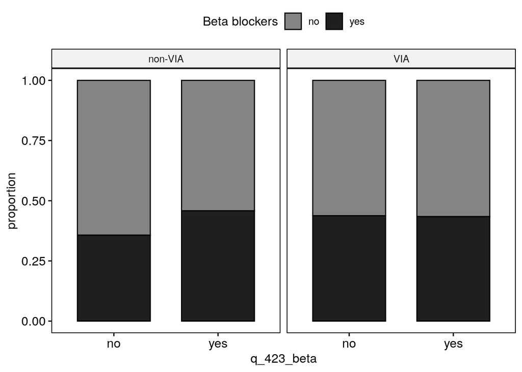

```
##
## Call:
## glm(formula = q_114_loss_of_consciousness ~ grouping * q_423_beta,
##     family = "binomial", data = age_sex_matched %>% filter(!is.na(q_423_beta),
##         q_423_beta != "unknown", q_114_loss_of_consciousness !=
##             "unknown", !is.na(grouping)) %>% mutate(grouping = car::recode(grouping,
##         "'insects'='VIA';'other'='non-VIA'")))
##
## Deviance Residuals:
##     Min       1Q   Median       3Q      Max
## -1.0600  -0.8257  -0.6282  -0.6282   1.8548
##
## Coefficients:
##                           Estimate Std. Error z value Pr(>|z|)
## (Intercept)               -1.52277    0.05053 -30.134  < 2e-16 ***
## groupingVIA                0.62189    0.06742   9.224  < 2e-16 ***
## q_423_betayes              0.70179    0.14579   4.814 1.48e-06 ***
## groupingVIA:q_423_betayes -0.08348    0.18756  -0.445    0.656
## ---
## Signif. codes:  0 '***' 0.001 '**' 0.01 '*' 0.05 '.' 0.1 ' ' 1
##
## (Dispersion parameter for binomial family taken to be 1)
##
##     Null deviance: 6371.9  on 5701  degrees of freedom
## Residual deviance: 6219.9  on 5698  degrees of freedom
## AIC: 6227.9
##
## Number of Fisher Scoring iterations: 4
```

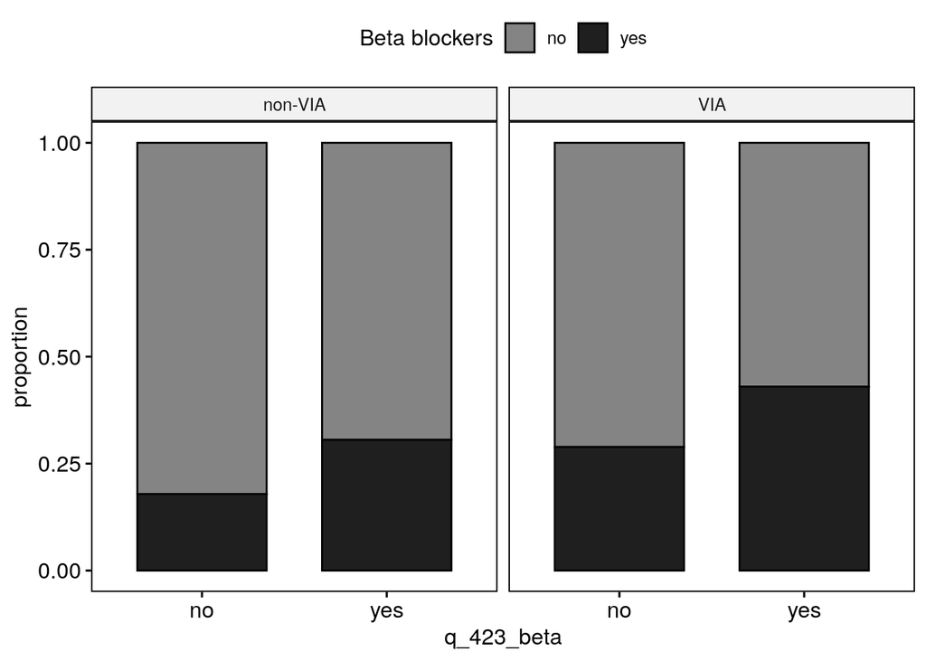

**MINOR COMMENTS: Line 147 mention BST values in Fig 3B but the figure should be 3C and D.**

Thank you for pointing that out. It has been corrected

## COMMENTS FROM REVIEWER #3:

**Reviewer #3: MAJOR COMMENTS:** **This report focuses on a sub-population of the European Anaphylaxis Registry and attempts to define phenotypes of insect sting anaphylaxis (VIA). This is therefore a study of severe insect sting anaphylaxis (VIA). The exclusion of patients with mild-to-moderate VIA provides a selected dataset and limits the generalizability of the results. The authors should point out at many points in the introduction, methods, results, and discussion, that this is a study limited to severe VIA and does not represent the full spectrum of VIA. There is a lack of depth in the references.**

Actually, this report considers mild, moderate and severe cases from grades II - IV according to Ring and Messmer, and we decided to to group the grades of 4 and 3 together as severe vs. moderate cases of grade II. We arrived at a distribution that was very suited vor statistical analysis as the two formed groups formed a nearly 50-50 split in VIA and non-VIA groups. Please inspect the figure 1D for details. Due to the reviewers comment we have revised the line 130 in the methods section as it was unclear that we also compared the severe cases (grades III+IV) to mild-to-moderate cases of grade II.

### MINOR COMMENTS:

**1. Line 117 Some mention should be made here, and in the discussion, of Stoevesandt et al, who reported on the risk factors for severe anaphylaxis to insect stings, and specifically identified the absence of urticaria as a major finding. (Stoevesandt J, Hain J, Kerstan A, Trautmann A. Over- and underestimated parameters in severe Hymenoptera venom-induced anaphylaxis: Cardiovascular medication and absence of urticaria/angioedema. J Allergy Clin Immunol. 2012;130:698-704.)**

Thank you for pointing that out, we added the references to this important study in our discussion and introduction sections.

**Line 134 The registry was designed for reporting of grades II - IV, but this study excluded grade II. This selection bias weakens the analysis.**

As answered in the major comment we used cases of grades II to IV in this study and this misunderstanding derives from not explicitly defining the mild-to-moderate group of cases formed of grade II anaphylaxis.

**Line 143-144 What was the distribution of cases in the 11 countries? Did one or two centers predominate?**

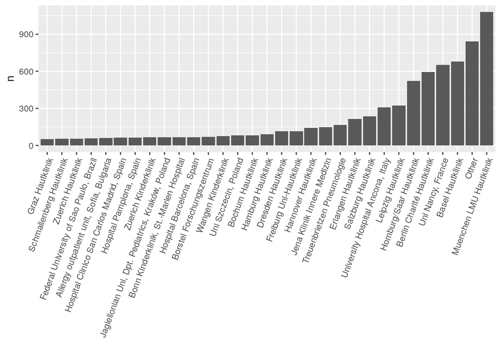

**Line 170 There is no p value here, and no detail in the figure.**

**Line 180-184 The frequency of hives reported here is in grade III/IV reactors (a selected population). Here, as in many other places, it would be preferred to refer to “patients undergoing severe VIA” so as to distinguish this population with severe anaphylaxis from the broader spectrum of patients who present with VIA.**

This comment derives from the major comment #1 and is no longer valid. Please see our explanation above.

**Line 226 The fact that 28% had a prior anaphylactic reaction to a sting is worthy of discussion. Is this a typical example of the failure of emergency and primary health care personnel to advise patients with sting anaphylaxis about he importance of allergy consultation for testing and preventative VIT?**

**Line 230 Note that the 10% frequency of more severe reaction was in patients selected for severe (grade III/IV) reactions. This does not address the frequency of more severe reactions in milder systemic reactors.**

This comment derives from the major comment #1 and is no longer valid. Please see our explanation above.

**Line 247 These were “moderate” not “mild” reactions, but they were milder than the severe (comparator) reactions. Mild anaphylactic reactions were excluded from the study.**

This comment derives from the major comment #1 and is no longer valid. Please see our explanation above.

**Line 277 It is not clear what is meant by “at the onset”**

**Line 277 The authors make an important point about the inherent selection bias of this study. This is specific to the use of the Ring and Messmer scale, in comparison with the Mueller grading scale, or the scale of Simon Brown (Brown SG. Clinical features and severity grading of anaphylaxis. J Allergy Clin Immunol. 2004;114:371-6.) The Ring scale emphasizes hypoxia as an element of the Grade 3 reaction and shock as the definition of the Grade 4 reaction. In other grading systems, both are considered severe, whereas moderate anaphylaxis might include patients with dyspnea, throat tightness, and moderate hypotensive symptoms. Thus the current study would be more likely to include patients with shock and hypoxia (and fewer cases of respiratory and cutaneous symptoms), than if it were to structure its definition of “moderate and severe anaphylaxis” on a different scale. It would be of interest to include an analysis of the Grade 2 reactors to provide another comparator with the phenotypes described in the current analysis.**

This comment derives from the major comment #1 and is no longer valid. Please see our explanation above.

**Lines 281-285 The discussion should include reference to previously published studies that have reported this finding. This study adds to our knowledge by the strength of numbers that permits comparison of those with and without mastocytosis.**

**Lines 281-285 These are important phenotypic correlations, showing the relation between BST levels, absence of urticaria, and severity of VIA. However, we must recall that the data are based on a population that excluded the majority of milder systemic reactors. The average allergist sees patients of all kinds with no study exclusions. It would be very useful to know how this paradigm fits in the patients with Grade II reactions.**

This comment derives from the major comment #1 and is no longer valid. Please see our explanation above.

**Line 294 I agree, but perhaps discussion should indicate the sensitivity of the test in these patients? Patients with a relatively low mast cell burden may have negative blood c-kit.**

**Line 316 One likely explanation for the under-use of epinephrine in VIA is the absence of urticaria in many cases, especially those with very severe reaction. Most physicians believe that “it is not anaphylaxis if there are no hives”.**

**Line 321 Do the authors mean “underestimate” rather than “undermine”?**

**Line 326 The observations of Smith et al would contradict the assumption that the tachycardia is psychological. (Smith PL, Kagey-Sobotka A, Bleecker ER, Traystman R, Kaplan AP, Gralnick H, et al. Physiologic manifestations of human anaphylaxis. J Clin Invest. 1980;66:1072-80.)**

**Lines 351-356 Any recommendation for management of VIA should include the indication for appropriate testing and immunotherapy.**

COMMENTS FROM THE EDITORIAL OFFICE: ** Change the colour of the title & headings to black ** Remove the date on the title page ** Please include a disclosure statement for all of the authors. If appropriate, you may state: “The rest of the authors declare that they have no relevant conflicts of interest.” ** Move the Disclosure statement to title page ** Please follow the JACI standard format for author names in references, according to Vancouver style. Examples are given in the Instructions for Authors. List all author names when there are six or fewer; when there are seven or more, list the first six and add et al. ** Upload each figure in the manuscript separately and place all of the figure legends together in a section after the references ** Upload each figure in the Online Repository separately and place all of the figure legends together in a section in the Online Repository text file. ** Include Table S1 in the Online Repository text file Your revision must include the following items: (1) point-by-point responses to the Editor and reviewer comments, (2) a marked copy of your revision showing the changes made, and (3) a clean (unmarked) copy of your revised manuscript. If your manuscript has any figures, tables, or Online Repository material in separate files, please be sure these are included in the revision as well. For further information regarding formatting of these elements, please consult the Guidelines for Submitting a Revision (found on the Editorial Manager homepage by clicking on Instructions for Authors). To avoid a delay in a final decision on your manuscript, please follow these instructions carefully. If you have questions or encounter difficulties in submitting your revised manuscript, please contact James Galipeau at jgalipeau@origineditorial.com, providing the title and manuscript number. Include interactive data visualizations in your publication and let your readers interact and engage more closely with your research. Follow the instructions here: https://www.elsevier.com/authors/author-services/data-visualization to find out about available data visualization options and how to include them with your article. Sincerely, The Editors The Journal of Allergy and Clinical Immunology The JACI is the #1 most-cited allergy/immunology journal, with an impact factor of 14.110.